# Module 4 Exercises

## Exercise for Module 4

**TipObjectives**

- Demonstrate record loading using sequencing variables.
- Cross-check between hospital admissions and death data to remove data errors.
- Construct survival time variable to estimate survival probability.

## Context

We will be using data provided and derived in Module 3 Exercises. and the death records relating to this patient subset, from 2000-2020.

1. All hospital admissions for patient subset

````markdown
```{r}
## Read in csv file
apdc_subset <- read_csv("https://raw.githubusercontent.com/NicoleDeLaMata/LinkedData/refs/heads/main/apdc_subset.csv")

## Convert date variables to date format then sort the data
apdc_subset <- apdc_subset %>%
  mutate(episode_start_date = dmy(episode_start_date),
         episode_end_date = dmy(episode_end_date),
         admdate_first = ymd(admdate_first),
         sepdate_last = ymd(sepdate_last)) %>%
  arrange(ppn, episode_start_date, episode_end_date)

```
````

2. Hospital admissions relating to patients first kidney transplant only

````markdown
```{r}
## Create a flag for patients with any admissions related to kidney transplant
diag_vars <- paste0("diagnosis_code", c("P", seq(1, 19)))
diag_vars

ktx_codes <- c("Z94")

analysis_ktx_data <- apdc_subset %>%
  mutate(ktx = 1 * if_any(all_of(diag_vars), ~ str_sub(.x, 1, 3) %in% ktx_codes))

## Create analysis dataset restricted to episodes of care related to kidney transplant
analysis_ktx_data1 <- analysis_ktx_data %>%
  filter(ktx == 1) %>%
  arrange(ppn, episode_start_date, episode_end_date) %>%
  group_by(ppn) %>%
  filter(row_number() == 1) %>%
  ungroup()
```
````

3. Death records relating to patient subset

````markdown
```{r}
## Read in csv file
dth_tx_subset <- read_csv("https://raw.githubusercontent.com/NicoleDeLaMata/LinkedData/refs/heads/main/dth_tx_subset.csv")

```
````

*Please note* that these are perturbed data based on administrative health data collected in NSW, Australia.

In this exercise, you will be using these data to practice your coding skills and familiarise yourself with linked health datasets.

## Question 1

Apply the provided transfers code *transfers()* to add variables to all hospital admissions dataset (**apdc_subset**) to identify which episodes of care belong to the same hospital admission.

How many periods of stay contained one or more transfers? What is the maximum number of transfers?

**CautionHint**

The solution should be the same as Module 3 Exercise - Question 10A

## Question 2

Only keep hospital admissions occurring after the first kidney transplant data, as given by the episode_start_date from the **analysis_ktx_data1** dataset.

How many patients with first kidney transplant were there? How many patients had hospital admissions after their first kidney transplant?

**CautionHint**

First merge in the necessary data from **analysis_ktx_data1** into the **apdc_subset** data derived from Question 1.

## Question 3

Using the resulting dataset from Question 2, identify hospital admissions that related to cardiovascular disease in any of the diagnosis fields. Cardiovascular disease is defined by ICD-10-AM codes including I20-I25, I34-I37, I42, I44-I49, I60-I61, and I63. Create a *cvd_flag* variable that takes a value of 1 for admissions relating to cardiovascular disease.

How many hospital admissions relating to cardiovascular disease were there after patients had their first kidney transplant?

## Question 4

Recall that we have already applied the transfers code *transfers()* in case any transfers occurred during the first kidney transplant and to ensure we captured the correct subsequent hospital admissions. However, as we then kept only hospital admissions following the first kidney transplant, several of the newly created variables would not technically still be correct.

*fileseq* would not be correct as we removed observations. *episode* and *stayseq* may be correct in certain circumstances (i.e. if their first hospital admission for the data period was the first kidney transplant) but generally would not always - although it is consecutively correct, it would not always start from 1 for the first observation for a patient. *transfer, transseq, admdate_first, sepdate_last* and *totlos* would all be correct.

Keeping this in mind, let’s start by reducing our dataset to the necessary variables (i.e. *ppn, stayseq, admdate_first, sepdate_last, totlos* and *cvd_flag*) and removing duplicates.Consider any additional data checks you may need to undertake to ensure the resulting dataset has one row per ppn per hospital admission. Then, we will recreate *fileseq* and create an index sequence varaible (*index_seq*) to flag the first admission with cardiovascular disease (if any) for each patient using the *cvd_flag*.

**NoteNote**

Reducing down our dataset at this stage is very useful for subsequent data manipulation steps that we will be undertaking. However, it is important to think ahead about what your analysis may need. It may be necessary to keep the other dataset variables too, or it may be easier to come back to these other dataset variables at a later stage. Remember, we have all the necessary variables to merge back and find these other data variables again.

An example of your resulting dataset is below.

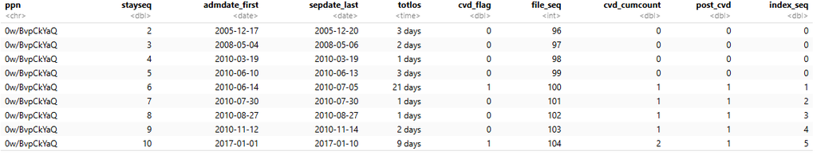

How many patients had at least one hospitalisation relating to cardiovascular disease after kidney transplant?

## Question 5

Retain all the records for patients who had at least one admission relating to cardiovascular disease (i.e. post_cvd = 1) into a new dataframe (**cvd_adm**). How many records are in this dataframe?

## Question 6

Let’s work on the deaths data (**dth_tx_subset**). Perform data checks (e.g remove duplicates, format dates) and ensure there is only one record per ppn.

## Question 7

Merge the deaths data with **cvd_adm**. Ensure you remove any death records that didn’t have a hospitalisation (i.e. left-join with keeping all observations from **cvd_adm**).

## Question 8

We will now be undertaking checks to identify inconsistencies in the death dates with the hospitalisation records, which may indicate a linkage or other error.

First, we need to find and merge in the *mode_of_separation_recode* for the last observation for each ppn and *admdate_first*.

Then, create a separate flag variable for each of the following types of inconsistency and report the total number of cases where these occurred:

1. Cases where *mode_of_separation_recode* indicates death with autopsy but there is no matching date of death.
2. Cases where *mode_of_separation_recode* indicates death without autopsy but there is no matching date of death.
3. Cases where the death occurred before admission date.
4. Cases where the death happened before the admission end date. Note that it is possible for date of death to be the day before admission end date, in cases where a patient dies late one day and the body is removed from the hospital the following day. Therefore, only flag those cases where the gap is more than one day.

## Question 9

Examine the records of the flagged patients. What kind of error does this appear to be?

To avoid relying on assumptions, delete all records for those patients flagged as having incorrect death dates.

## Question 10

Create an analysis dataset (**analysis_data**) including only the index admission relating to cardiovascular disease for each patient. Create a *final_date* variable for all patients. This should be the end of the study period (31 December 2020) or their date of death, whichever comes first.

**CautionHint**

Use pmin() to determine the minimum across each row.

## Question 11

Create the survival time (*survtime*) from *admdate_first* of the index admission until the *final_date* and censoring variable (*status*) to indicate whether the patient died before the end of the study period. If the survtime variable is 0, recode to 1 day. Convert the survival time to be in years, rather than days.

What is the median survival time for those who died compared to those who survived?

## Question 12

Plot the overall survival curve. Using this plot, what is the approximate survival probability at 5 years?

## Question 13

Find the proportion of patients who survived for:

1. 6 months.
2. 1 year.
3. 3 years.